# IODS course project

# Import data

Read data from own data folder.

```r
alc <- read.csv("C:/Users/juhol/OneDrive/Documents/GitHub/IODS-project/data/alc.csv", header = T, sep = ",")

alc <- alc[,-1] # First column only duplicates the row numbers

dim(alc)
```

```
## [1] 382  35
```

```r
str(alc)
```

```
## 'data.frame':    382 obs. of  35 variables:
##  $ school    : Factor w/ 2 levels "GP","MS": 1 1 1 1 1 1 1 1 1 1 ...
##  $ sex       : Factor w/ 2 levels "F","M": 1 1 1 1 1 2 2 1 2 2 ...
##  $ age       : int  18 17 15 15 16 16 16 17 15 15 ...
##  $ address   : Factor w/ 2 levels "R","U": 2 2 2 2 2 2 2 2 2 2 ...
##  $ famsize   : Factor w/ 2 levels "GT3","LE3": 1 1 2 1 1 2 2 1 2 1 ...
##  $ Pstatus   : Factor w/ 2 levels "A","T": 1 2 2 2 2 2 2 1 1 2 ...
##  $ Medu      : int  4 1 1 4 3 4 2 4 3 3 ...
##  $ Fedu      : int  4 1 1 2 3 3 2 4 2 4 ...
##  $ Mjob      : Factor w/ 5 levels "at_home","health",..: 1 1 1 2 3 4 3 3 4 3 ...
##  $ Fjob      : Factor w/ 5 levels "at_home","health",..: 5 3 3 4 3 3 3 5 3 3 ...
##  $ reason    : Factor w/ 4 levels "course","home",..: 1 1 3 2 2 4 2 2 2 2 ...
##  $ nursery   : Factor w/ 2 levels "no","yes": 2 1 2 2 2 2 2 2 2 2 ...
##  $ internet  : Factor w/ 2 levels "no","yes": 1 2 2 2 1 2 2 1 2 2 ...
##  $ guardian  : Factor w/ 3 levels "father","mother",..: 2 1 2 2 1 2 2 2 2 2 ...
```

[output cut: 21 more lines]

```r
summary(alc)
```

```
##  school   sex          age        address famsize   Pstatus
##  GP:342   F:198   Min.   :15.00   R: 81   GT3:278   A: 38
##  MS: 40   M:184   1st Qu.:16.00   U:301   LE3:104   T:344
##                   Median :17.00
##                   Mean   :16.59
##                   3rd Qu.:17.00
##                   Max.   :22.00
##       Medu            Fedu             Mjob           Fjob
##  Min.   :0.000   Min.   :0.000   at_home : 53   at_home : 16
##  1st Qu.:2.000   1st Qu.:2.000   health  : 33   health  : 17
##  Median :3.000   Median :3.000   other   :138   other   :211
##  Mean   :2.806   Mean   :2.565   services: 96   services:107
##  3rd Qu.:4.000   3rd Qu.:4.000   teacher : 62   teacher : 31
##  Max.   :4.000   Max.   :4.000
##         reason    nursery   internet    guardian     traveltime
##  course    :140   no : 72   no : 58   father: 91   Min.   :1.000
##  home      :110   yes:310   yes:324   mother:275   1st Qu.:1.000
##  other     : 34                       other : 16   Median :1.000
##  reputation: 98                                    Mean   :1.448
##                                                    3rd Qu.:2.000
##                                                    Max.   :4.000
##    studytime        failures      schoolsup famsup     paid     activities
##  Min.   :1.000   Min.   :0.0000   no :331   no :144   no :205   no :181
##  1st Qu.:1.000   1st Qu.:0.0000   yes: 51   yes:238   yes:177   yes:201
##  Median :2.000   Median :0.0000
##  Mean   :2.037   Mean   :0.2016
##  3rd Qu.:2.000   3rd Qu.:0.0000
##  Max.   :4.000   Max.   :3.0000
##  higher    romantic      famrel         freetime        goout
##  no : 18   no :261   Min.   :1.000   Min.   :1.00   Min.   :1.000
##  yes:364   yes:121   1st Qu.:4.000   1st Qu.:3.00   1st Qu.:2.000
##                      Median :4.000   Median :3.00   Median :3.000
##                      Mean   :3.937   Mean   :3.22   Mean   :3.113
##                      3rd Qu.:5.000   3rd Qu.:4.00   3rd Qu.:4.000
##                      Max.   :5.000   Max.   :5.00   Max.   :5.000
##       Dalc            Walc           health         absences
##  Min.   :1.000   Min.   :1.000   Min.   :1.000   Min.   : 0.0
##  1st Qu.:1.000   1st Qu.:1.000   1st Qu.:3.000   1st Qu.: 1.0
##  Median :1.000   Median :2.000   Median :4.000   Median : 3.0
##  Mean   :1.482   Mean   :2.296   Mean   :3.573   Mean   : 4.5
##  3rd Qu.:2.000   3rd Qu.:3.000   3rd Qu.:5.000   3rd Qu.: 6.0
##  Max.   :5.000   Max.   :5.000   Max.   :5.000   Max.   :45.0
##        G1              G2              G3           alc_use
##  Min.   : 2.00   Min.   : 4.00   Min.   : 0.00   Min.   :1.000
##  1st Qu.:10.00   1st Qu.:10.00   1st Qu.:10.00   1st Qu.:1.000
##  Median :12.00   Median :12.00   Median :12.00   Median :1.500
##  Mean   :11.49   Mean   :11.47   Mean   :11.46   Mean   :1.889
##  3rd Qu.:14.00   3rd Qu.:14.00   3rd Qu.:14.00   3rd Qu.:2.500
##  Max.   :18.00   Max.   :18.00   Max.   :18.00   Max.   :5.000
##   high_use
##  Mode :logical
##  FALSE:268
##  TRUE :114
##
##
##
```

Data icludes 382 observations and 35 variables. Data is combined from two datasets which are loaded from [here](https://archive.ics.uci.edu/ml/machine-learning-databases/00320/). Site includes also the meta text for data which is usefull to read. R-code for data wrangling can be found in [here](https://github.com/juholaht/IODS-project/blob/master/data/create_alc.R) and data is available in [here](https://github.com/juholaht/IODS-project/blob/master/data/alc.csv).

# Analysis

Packages used in this section:

```r
library(dplyr)
library(tidyverse)
library(ggplot2)
library(GGally)
library(cowplot)
library(boot)
```

Lets introduce the column names of our data.

```r
colnames(alc)
```

```
##  [1] "school"     "sex"        "age"        "address"    "famsize"
##  [6] "Pstatus"    "Medu"       "Fedu"       "Mjob"       "Fjob"
## [11] "reason"     "nursery"    "internet"   "guardian"   "traveltime"
## [16] "studytime"  "failures"   "schoolsup"  "famsup"     "paid"
## [21] "activities" "higher"     "romantic"   "famrel"     "freetime"
## [26] "goout"      "Dalc"       "Walc"       "health"     "absences"
## [31] "G1"         "G2"         "G3"         "alc_use"    "high_use"
```

In our analyse section we are interested in relationships between alcohol consumption and social parameters. Lets choose variable “high use of alcohol” (binary) as the dependent variable of interest and “extra-curricular activities” (binary), “romantic relationship” (binary), “quality of family relationships” (numeric: from 1 - very bad to 5 - excellent) and “going out with friends” (numeric: from 1 - very low to 5 - very high) as social parameters of interest. Lets also control the age and sex.

```r
# Lets make subset of data with variables "sex", "age", "activities", "romantic", "famrel", "goout" and "high_use".

variables_sub <- c("sex", "age", "activities", "romantic", "famrel", "goout", "high_use")

alc_sub <- select(alc, one_of(variables_sub))

str(alc_sub)
```

```
## 'data.frame':    382 obs. of  7 variables:
##  $ sex       : Factor w/ 2 levels "F","M": 1 1 1 1 1 2 2 1 2 2 ...
##  $ age       : int  18 17 15 15 16 16 16 17 15 15 ...
##  $ activities: Factor w/ 2 levels "no","yes": 1 1 1 2 1 2 1 1 1 2 ...
##  $ romantic  : Factor w/ 2 levels "no","yes": 1 1 1 2 1 1 1 1 1 1 ...
##  $ famrel    : int  4 5 4 3 4 5 4 4 4 5 ...
##  $ goout     : int  4 3 2 2 2 2 4 4 2 1 ...
##  $ high_use  : logi  FALSE FALSE TRUE FALSE FALSE FALSE ...
```

Lets plot alcohol use which each of these variables.

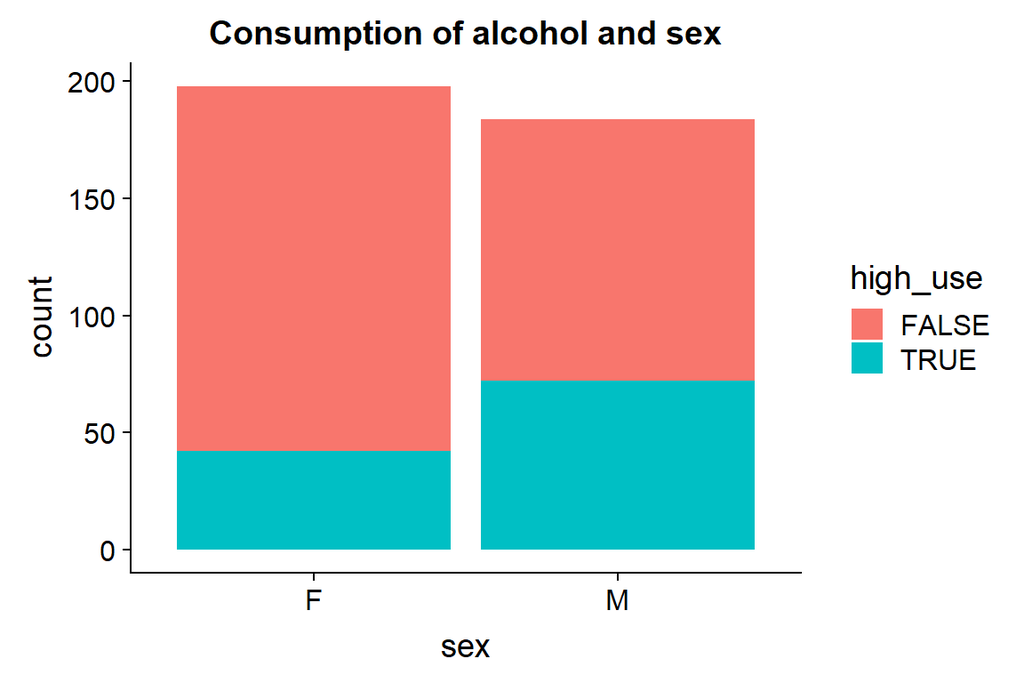

```r
alc_sex <- ggplot(data = alc_sub, aes(x = sex, fill = high_use)) + geom_bar() + ggtitle("Consumption of alcohol and sex")

alc_sex
```

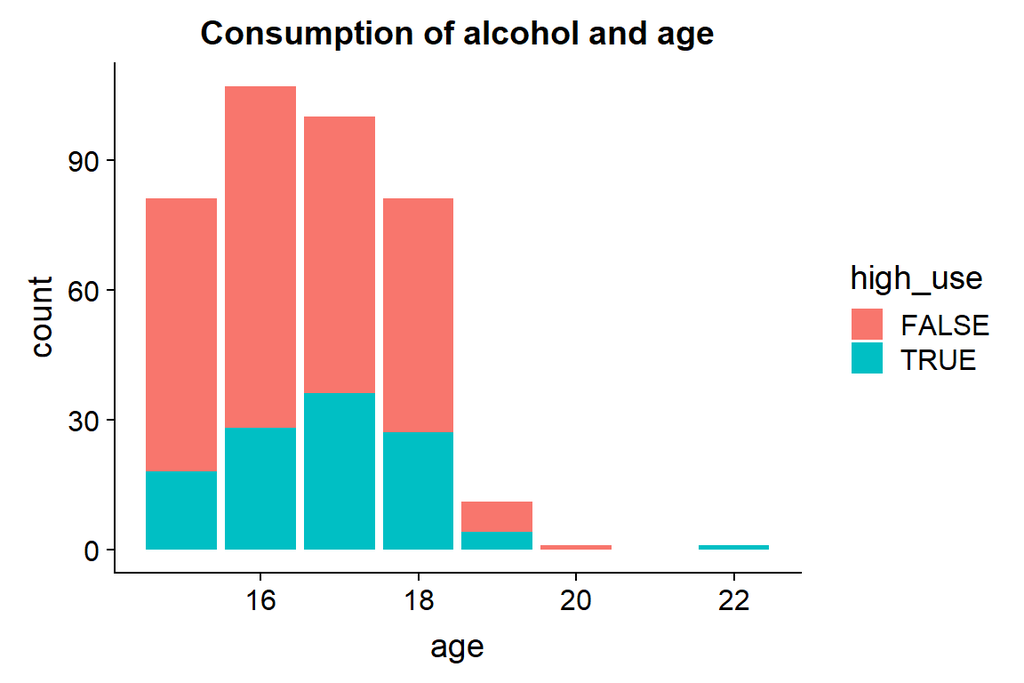

```r
alc_age <- ggplot(data = alc_sub, aes(x = age, fill = high_use)) + geom_bar() + ggtitle("Consumption of alcohol and age")

alc_age
```

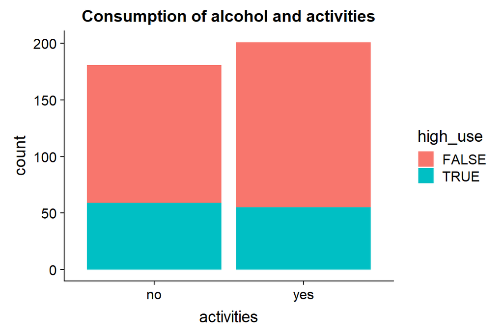

```r
alc_act <- ggplot(data = alc_sub, aes(x = activities, fill = high_use)) + geom_bar() + ggtitle("Consumption of alcohol and activities")

alc_act
```

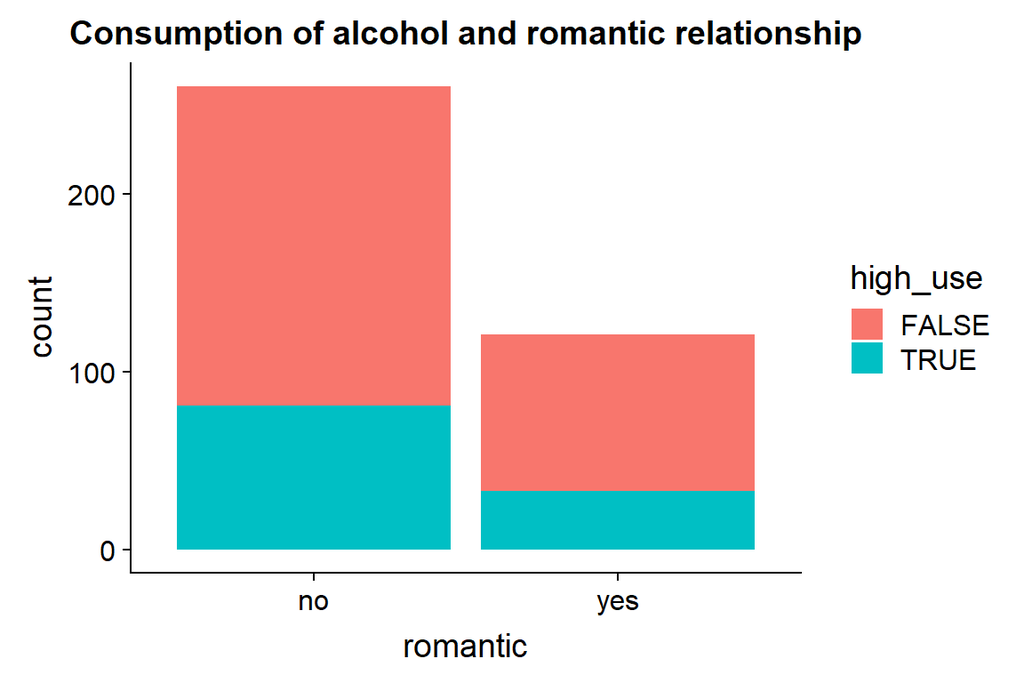

```r
alc_rom <- ggplot(data = alc_sub, aes(x = romantic, fill = high_use)) + geom_bar() + ggtitle("Consumption of alcohol and romantic relationship")

alc_rom
```

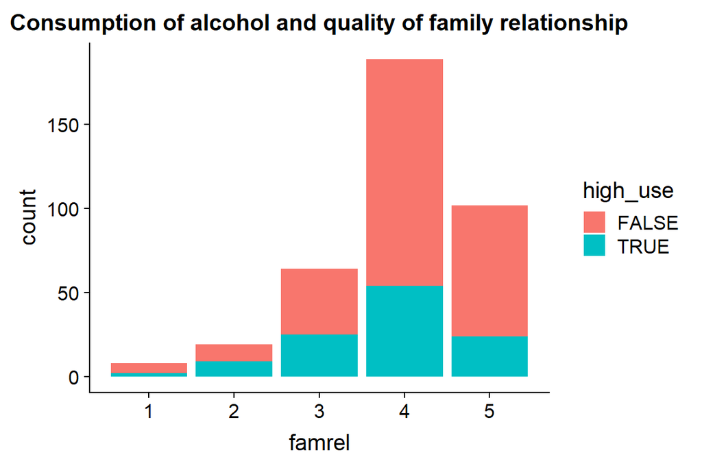

```r
alc_family <- ggplot(data = alc_sub, aes(x = famrel, fill = high_use)) + geom_bar() + ggtitle("Consumption of alcohol and quality of family relationship")

alc_family
```

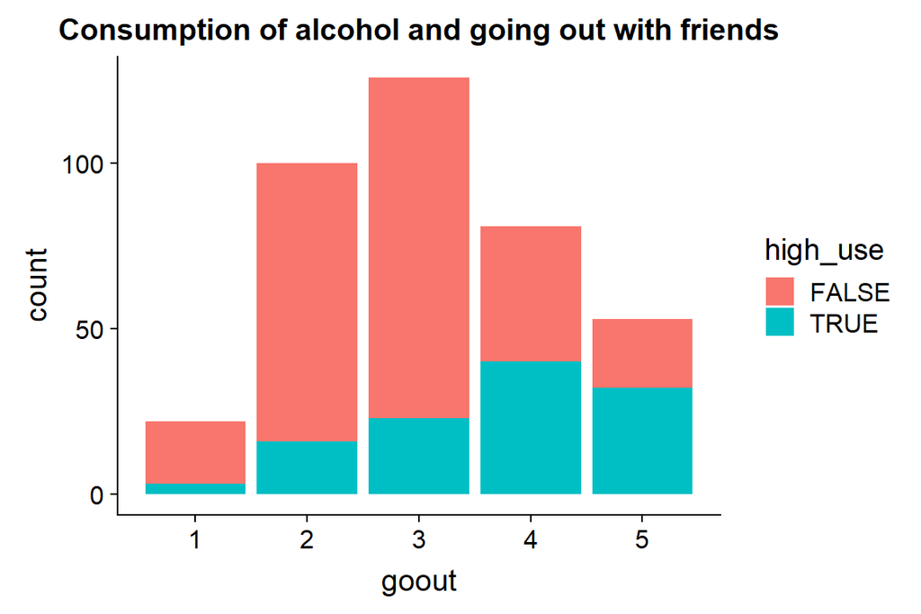

```r
alc_goout <- ggplot(data = alc_sub, aes(x = goout, fill = high_use)) + geom_bar() + ggtitle("Consumption of alcohol and going out with friends")

alc_goout
```

Lets looking this in more detail. Lets start from GLM-model
$$\text{HighUse}_{i} = \beta_{0} + \beta_{1}\text{Sex}_{i} + \beta_{2}\text{Age}_{i} + \beta_{3}\text{Activities}_{i} + \beta_{4}\text{Romantic}_{i} + \beta_{5}\text{Family}_{i} + \beta_{6}\text{GoOut}_{i} + \epsilon_{i}$$
and then using the backward method for finding the best candidate for the best linear model.

```r
# First model
glm1 <- glm(high_use ~ sex + age + activities + romantic + famrel + goout, data = alc_sub, family = "binomial")

step(glm1, direction = "backward")
```

```
## Start:  AIC=402.06
## high_use ~ sex + age + activities + romantic + famrel + goout
##
##              Df Deviance    AIC
## - romantic    1   389.00 401.00
## - age         1   389.99 401.99
## <none>            388.06 402.06
## - activities  1   390.86 402.86
## - famrel      1   397.30 409.30
## - sex         1   403.62 415.62
## - goout       1   436.48 448.48
##
## Step:  AIC=401
## high_use ~ sex + age + activities + famrel + goout
##
##              Df Deviance    AIC
## - age         1   390.62 400.62
## <none>            389.00 401.00
## - activities  1   391.99 401.99
## - famrel      1   397.84 407.84
## - sex         1   405.01 415.01
## - goout       1   437.32 447.32
##
## Step:  AIC=400.62
## high_use ~ sex + activities + famrel + goout
##
##              Df Deviance    AIC
## <none>            390.62 400.62
## - activities  1   393.80 401.80
## - famrel      1   399.15 407.15
## - sex         1   406.47 414.47
## - goout       1   442.61 450.61
```

```
##
## Call:  glm(formula = high_use ~ sex + activities + famrel + goout, family = "binomial",
##     data = alc_sub)
##
## Coefficients:
##   (Intercept)           sexM  activitiesyes         famrel          goout
##       -2.2313         0.9971        -0.4494        -0.4050         0.8118
##
## Degrees of Freedom: 381 Total (i.e. Null);  377 Residual
## Null Deviance:       465.7
## Residual Deviance: 390.6     AIC: 400.6
```

By Akaike information criterion the best model is the following:
$$\text{HighUse}_{i} = \beta_{0} + \beta_{1}\text{Sex}_{i} + \beta_{2}\text{Activities}_{i} + \beta_{3}\text{Family}_{i} + \beta_{4}\text{GoOut}_{i} + \epsilon_{i}$$

This model has $\text{AIC} = 400.6$.

```r
glm_best <- glm(formula = high_use ~ sex + activities + famrel + goout, family = "binomial",
    data = alc_sub)

summary(glm_best)
```

```
##
## Call:
## glm(formula = high_use ~ sex + activities + famrel + goout, family = "binomial",
##     data = alc_sub)
##
## Deviance Residuals:
##     Min       1Q   Median       3Q      Max
## -1.5303  -0.7884  -0.5366   0.8617   2.6530
##
## Coefficients:
##               Estimate Std. Error z value Pr(>|z|)
## (Intercept)    -2.2313     0.6476  -3.445  0.00057 ***
## sexM            0.9971     0.2559   3.896 9.77e-05 ***
## activitiesyes  -0.4494     0.2532  -1.775  0.07588 .
## famrel         -0.4050     0.1396  -2.902  0.00371 **
## goout           0.8118     0.1229   6.603 4.03e-11 ***
## ---
## Signif. codes:  0 '***' 0.001 '**' 0.01 '*' 0.05 '.' 0.1 ' ' 1
##
## (Dispersion parameter for binomial family taken to be 1)
##
##     Null deviance: 465.68  on 381  degrees of freedom
## Residual deviance: 390.62  on 377  degrees of freedom
## AIC: 400.62
##
## Number of Fisher Scoring iterations: 4
```

We can calculate $\text{McFadden's Pseudo} R^2$ representing the overall effect size of the model (more about from [here](http://www.glmj.org/archives/articles/Smith_v39n2.pdf)):

```r
ll.null <- glm_best$null.deviance/-2
ll.proposed <- glm_best$deviance/-2

pseudo_r_sqr <- (ll.null-ll.proposed)/ll.null

pseudo_r_sqr
```

```
## [1] 0.1611876
```

```r
ll.null2 <- glm1$null.deviance/-2
ll.proposed2 <- glm1$deviance/-2

pseudo_r_sqr_org <- (ll.null2-ll.proposed2)/ll.null2

pseudo_r_sqr_org
```

```
## [1] 0.1666838
```

We get that $\text{McFadden's Pseudo} R^2 = 0.16$ which is relatively small. The original model has $\text{McFadden's Pseudo} R^2 = 0.17$ so having extra variables does not increase the effect size significantly.

In this model all other variables (including the intercept) but “extra-curricular activities” (binary) are statistically significant (counted by Wald-test) in 99 % confidence level. Also variable “extra-curricular activities” is significant in 90 % confidence level. All the coefficients are in “log(odds)” -format. With binary variables, coefficient is represinting the “log(odds ratio)” -format, for example variable sex has $log(\text{odd ratio}) = 0.9971 \Leftrightarrow \text{odd ratio} = 2.71041$. The social variables which were the variables of our interest, having extra-curricular activities has an negative effect to high consumption of alcohol as the good family relationships also does, both with log(odd) -estimation around -0.40 - -0.50. Going out with friends has a positive effect to heavy drinking, $log(\text{odd}) = 0.8118 \Leftrightarrow \text{odd} = 2.251958$, meaning that approximately the ratio between heavy drinkers of those who go out and those how don’t is $\frac{5}{2}$.

We can provide 2x2 cross tabulation of predictions versus the actual values. Lets also have a visual look up, how our model “fitted” with data.

```r
## Predicted values of our model
predicted_data <- data.frame(
  probability_of_hc = glm_best$fitted.values,
  high_consumption = alc_sub$high_use)

predicted_data <- mutate(predicted_data, prediction = probability_of_hc > 0.5)

predicted_data <- predicted_data[  order(predicted_data$probability_of_hc, decreasing=FALSE),]

predicted_data$rank <- 1:nrow(predicted_data)

# head(predicted_data)

# tabulate the target variable versus the predictions
table(high_use = predicted_data$high_consumption, prediction = predicted_data$prediction)
```

```
##         prediction
## high_use FALSE TRUE
##    FALSE   254   14
##    TRUE     75   39
```

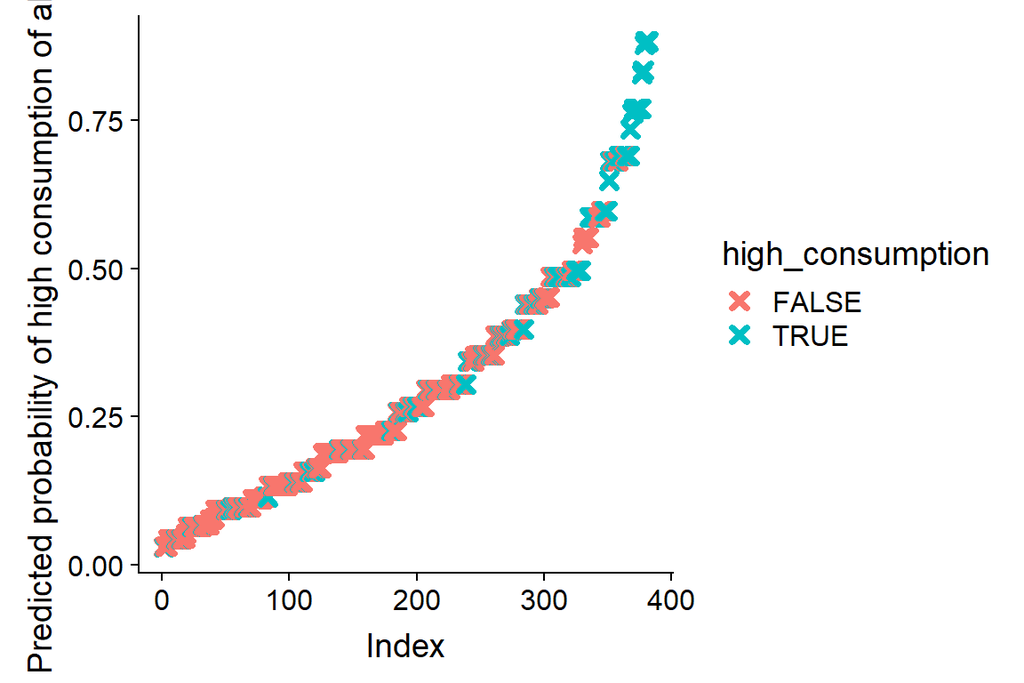

```r
# Plotting
ggplot(data=predicted_data, aes(x=rank, y=probability_of_hc)) +
  geom_point(aes(color=high_consumption), alpha=1, shape=4, stroke=2) +
  xlab("Index") +
  ylab("Predicted probability of high consumption of alcohol")
```

Lets do this also with cross-validation for the model.

```r
# define a loss function (average prediction error)
loss_func <- function(class, prob) {
  n_wrong <- abs(class - prob) > 0.5
  mean(n_wrong)
}

# Average number of wrong predictions in the (training) data

loss_func(predicted_data$high_consumption, predicted_data$probability_of_hc)
```

```
## [1] 0.2329843
```

```r
# 10-fold cross-validation

cv <- cv.glm(data = alc_sub, cost = loss_func, glmfit = glm_best, K = 10)

# Average number of wrong predictions in the cross validation
cv$delta[1]
```

```
## [1] 0.2565445
```

```r
# For comparing, lets try probabilities P(High_use) = 1 and 0

# P(High_use) = 1
loss_func(predicted_data$high_consumption, prob = 1)
```

```
## [1] 0.7015707
```

```r
# P(High_use) = 0
loss_func(predicted_data$high_consumption, prob = 0)
```

```
## [1] 0.2984293
```